# House Prices in New York

Group CC901E2: SID’s

The University of Sydney

# Introduction

# More Discussion

Model stability

## `mplot` package

It takes some time to create the `vis` and `af` objects for plotting variable inclusion plot and model stability plot, so we can save it as `RData`.

```r
vis.h = mplot::vis(lm.h.f, B = 100, seed = 2022)
af.h <- mplot::af(lm.h.f, B = 100, n.c = 300, seed = 2022)
save(vis.h, af.h, file = "house_main.RData")
```

Then, load it when we need.

```r
load("house_main.RData")
```

## Variable Inclusion Plot

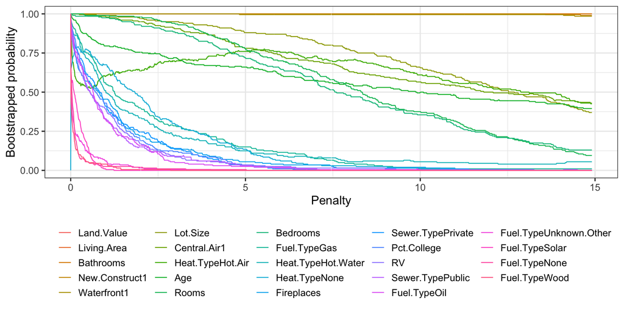

```r
plot(vis.h, which = "vip", interactive = FALSE, legend.position = "bottom")
```

## Variable Inclusion Plot: Insight

- `Land.Value`, `Living.Area`, `Bathrooms`, `New.Construct`, `Waterfront` are the five most important variables for predicting `Price`.
- The non-monotonic nature of the `HeatTypeHot.Air` line indicates that a group of variables contains similar information to it.
- The path of `Sewer.TypePublic` and all levels of `FuelType` lie below the path of redundant variable, which means they are included in models by chance (don’t provide any useful information).

## Model stability Plot

- There appears to be dominant models in models of size **two, three, and five** (including the intercept), as demonstrated by one of the circles being substantially larger than the other circles with models of the same size.
- The stepwise model (size = 14) is not stable as all circles of that size are small.

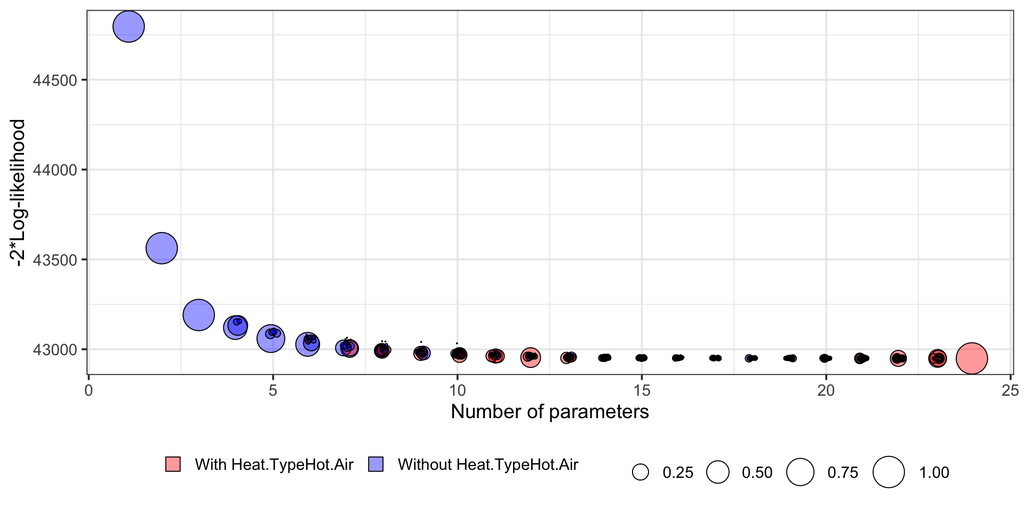

```r
plot(vis.h, highlight = "Heat.TypeHot.Air", which = "boot", interaction = F, max.circle = 10, seed = 2022, legend.position = "bottom")
```

## Which models are dominant?

```r
print(vis.h, min.prob = 0.5)
```

```
                                                              name prob
                                                           Price~1 1.00
                                                 Price~Living.Area 1.00
                                      Price~Land.Value+Living.Area 1.00
                            Price~Land.Value+Living.Area+Bathrooms 0.56
                Price~Waterfront1+Land.Value+Living.Area+Bathrooms 0.78
 Price~Waterfront1+Land.Value+New.Construct1+Living.Area+Bathrooms 0.57
 logLikelihood
     -22398.09
     -21781.28
     -21595.32
     -21560.23
     -21529.76
     -21513.72
```

- The simple regression model $\{Living.Area\}$ and $\{Land.Value, Living.Area\}$ model are selected in all bootstrap resamples.
- The $\{Waterfront1, Land.Value, Living.Area, Bathrooms\}$ model is selected in 78% of bootstrap resamples.